# 09-myeloid-milor-analysis

Bicna Song

2026-07-27

## Setup

This block loads the packages required for converting the Seurat object to a `SingleCellExperiment`, running miloR, and saving tabular and plot outputs.

```r
suppressPackageStartupMessages({
  library(rprojroot)
  library(dplyr)
  library(tibble)
  library(Seurat)
  library(SeuratObject)
  library(SingleCellExperiment)
  library(miloR)
  library(ggplot2)
})

root_dir <- find_root(has_dir(".git"))
data_dir <- file.path(root_dir, "data", "v5")
analysis_dir <- file.path(root_dir, "analyses", "downstream-analyses")
results_dir <- file.path(analysis_dir, "results", "myeloid")
plot_dir <- file.path(analysis_dir, "plots", "myeloid")

source(file.path(analysis_dir, "util", "milor_helpers.R"))

set_seed(1234)
```

## Parameters

This block records the input object, metadata columns, miloR graph settings, and reference conditions used for all contrasts.

```r
input_rds <- params$input_rds
subtype_label <- params$subtype_label
condition_levels <- params$condition_levels
reference_conditions <- params$reference_conditions
milo_reduction <- params$milo_reduction
milo_plot_reduction <- params$milo_plot_reduction
milo_dims <- params$milo_dims
milo_k <- params$milo_k
milo_prop <- params$milo_prop
save_neighborhood_graphs <- params$save_neighborhood_graphs

cell_group_col <- paste0(subtype_label, "_subtype")

# output label
analysis_label <- cell_group_col

cat("Input RDS:", input_rds, "\n")
```

```
## Input RDS: cart_myeloid_subtypes.rds
```

```r
cat("Cell group column:", cell_group_col, "\n")
```

```
## Cell group column: myeloid_subtype
```

```r
cat("Condition levels:", paste(condition_levels, collapse = ", "), "\n")
```

```
## Condition levels: 41BB-L, B7H3, CD28-41BB, CD8-41BB, STOP, tumor
```

```r
cat("Reference conditions:", paste(reference_conditions, collapse = ", "), "\n")
```

```
## Reference conditions: tumor, STOP
```

```r
cat("Milo reduction:", milo_reduction, "\n")
```

```
## Milo reduction: INTEGRATED.CCA
```

```r
cat("Milo plotting reduction:", milo_plot_reduction, "\n")
```

```
## Milo plotting reduction: UMAP
```

```r
cat("Milo dims:", milo_dims, "\n")
```

```
## Milo dims: 20
```

```r
cat("Milo k:", milo_k, "\n")
```

```
## Milo k: 30
```

```r
cat("Milo neighborhood sampling proportion:", milo_prop, "\n")
```

```
## Milo neighborhood sampling proportion: 0.1
```

```r
cat("Save native miloR neighborhood graphs:", save_neighborhood_graphs, "\n")
```

```
## Save native miloR neighborhood graphs: FALSE
```

## Load Myeloid Object

This block loads the myeloid Seurat object and checks that the metadata required by miloR is present.

```r
obj <- readRDS(file.path(data_dir, input_rds))

stopifnot(cell_group_col %in% colnames(obj@meta.data))
stopifnot("sample" %in% colnames(obj@meta.data))
stopifnot("condition" %in% colnames(obj@meta.data))
stopifnot(all(reference_conditions %in% condition_levels))

table(obj$condition)
```

```
##
##    41BB-L      B7H3 CD28-41BB  CD8-41BB      STOP     tumor
##     17118     20794     22072     17230     15089     11528
```

```r
table(obj@meta.data[[cell_group_col]])
```

```
##
##                      Early activated microglia
##                                          13385
##                  TAM-like phagocytic microglia
##                                          12312
##                      Stress-response microglia
##                                          23601
##               Inflammatory activated microglia
##                                          10155
##                                Angiogenic TAMs
##                                          10155
##                        Antigen-presenting TAMs
##                                           8390
##                          Homeostatic microglia
##                                           8066
##                       Perivascular macrophages
##                                           3769
##                          Lipid-associated TAMs
##                                           3525
## Perivascular macrophages (chemokine-producing)
##                                           2858
##                   Antigen-presenting monocytes
##                                           2475
##                              Inflammatory TAMs
##                                           2299
##                                           cDC1
##                                           1615
##                         Inflammatory monocytes
##                                           1226
```

## Prepare SingleCellExperiment

This block converts the Seurat object to a `SingleCellExperiment`, standardizes metadata names, and copies Seurat reductions if they were not transferred automatically.

```r
milo_prepared <- prepare_milo_sce(
  obj = obj,
  cell_group_col = cell_group_col,
  condition_levels = condition_levels,
  milo_reduction = milo_reduction,
  milo_plot_reduction = milo_plot_reduction,
  milo_dims = milo_dims
)

milo_sce <- milo_prepared$sce
milo_d <- milo_prepared$d
milo_layout <- milo_prepared$layout

cat("Milo graph reduction:", milo_reduction, "\n")
```

```
## Milo graph reduction: INTEGRATED.CCA
```

```r
cat("Milo graph dimensions:", milo_d, "\n")
```

```
## Milo graph dimensions: 20
```

```r
cat("Milo plot layout:", milo_layout, "\n")
```

```
## Milo plot layout: UMAP
```

## Build Milo Neighborhoods

This block builds the KNN graph, samples representative neighborhoods, and counts cells per biological sample for differential abundance testing.

```r
milo_obj <- build_milo_neighborhoods(
  milo_sce = milo_sce,
  milo_reduction = milo_reduction,
  milo_d = milo_d,
  milo_k = milo_k,
  milo_prop = milo_prop,
  plot_size_hist = TRUE
)
```

[output not shown]

## Build Design Matrix

This block creates one row per sample for miloR and aligns the design table to the neighborhood count matrix.

```r
milo_design <- build_milo_design(milo_obj, reference_conditions)

table(milo_design$condition)
```

```
##
##    41BB-L      B7H3 CD28-41BB  CD8-41BB      STOP     tumor
##         2         2         2         2         2         2
```

## Test Neighborhood Differential Abundance

This block tests each condition against each selected reference and annotates neighborhoods by the dominant myeloid subtype.

```r
milo_reference_results <- stats::setNames(vector("list", length(reference_conditions)), reference_conditions)

for (reference_condition in reference_conditions) {
  milo_test <- run_milo_da(
    milo_obj = milo_obj,
    milo_design = milo_design,
    condition_levels = condition_levels,
    reference_condition = reference_condition,
    milo_reduction = milo_reduction,
    milo_d = milo_d
  )

  milo_obj <- milo_test$milo_obj
  milo_da_results <- milo_test$da_results

  write.table(
    milo_da_results,
    file = file.path(results_dir, paste0(analysis_label, "_milor_", safe_label(reference_condition), "_baseline_results.tsv")),
    sep = "\t",
    quote = FALSE,
    row.names = FALSE
  )

  milo_reference_results[[reference_condition]] <- list(
    da_results = milo_da_results,
    contrasts = milo_test$contrasts
  )
}
```

```
## Running Milo contrast: 41BB-L vs tumor
## Running Milo contrast: B7H3 vs tumor
## Running Milo contrast: CD28-41BB vs tumor
## Running Milo contrast: CD8-41BB vs tumor
## Running Milo contrast: STOP vs tumor
## Running Milo contrast: 41BB-L vs STOP
## Running Milo contrast: B7H3 vs STOP
## Running Milo contrast: CD28-41BB vs STOP
## Running Milo contrast: CD8-41BB vs STOP
## Running Milo contrast: tumor vs STOP
```

## Summarize MiloR Trends by Myeloid Subtype

This block summarizes FDR-adjusted and nominal neighborhoods by annotated myeloid subtype. The plots emphasize nominal `PValue` trends and effect sizes, and should not be interpreted as FDR-significant DA calls unless neighborhoods pass the adjusted thresholds.

```
## Milo reference condition: tumor
## # A tibble: 5 × 9
##   comparison       n_neighborhoods min_p_value min_fdr min_spatial_fdr n_nominal
##   <chr>                      <int>       <dbl>   <dbl>           <dbl>     <int>
## 1 41BB-L vs tumor             7240    0.000269   0.239           0.323       849
## 2 B7H3 vs tumor               7240    0.000149   0.131           0.149      1303
## 3 CD28-41BB vs tu…            7240    0.000389   0.377           0.503       552
## 4 CD8-41BB vs tum…            7240    0.000298   0.125           0.125      1553
## 5 STOP vs tumor               7240    0.00195    1               0.978       293
## # ℹ 3 more variables: n_fdr_0_05 <int>, n_spatial_fdr_0_05 <int>,
## #   max_abs_logFC <dbl>
## No neighborhoods pass SpatialFDR < 0.05 in any contrast.
```

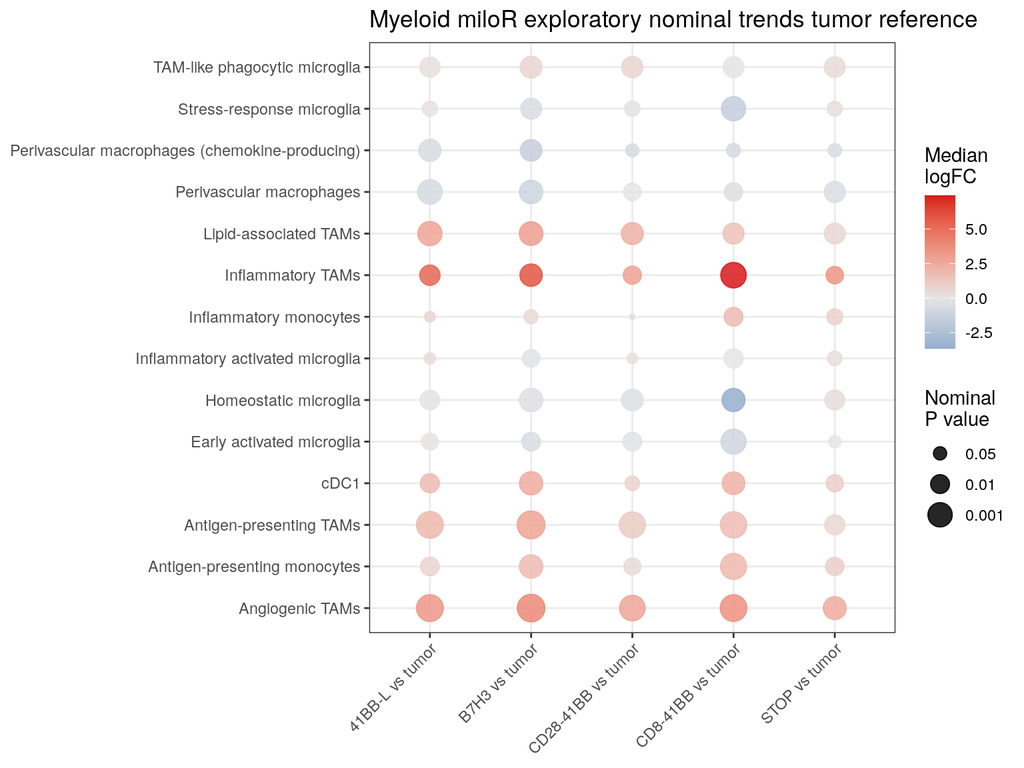

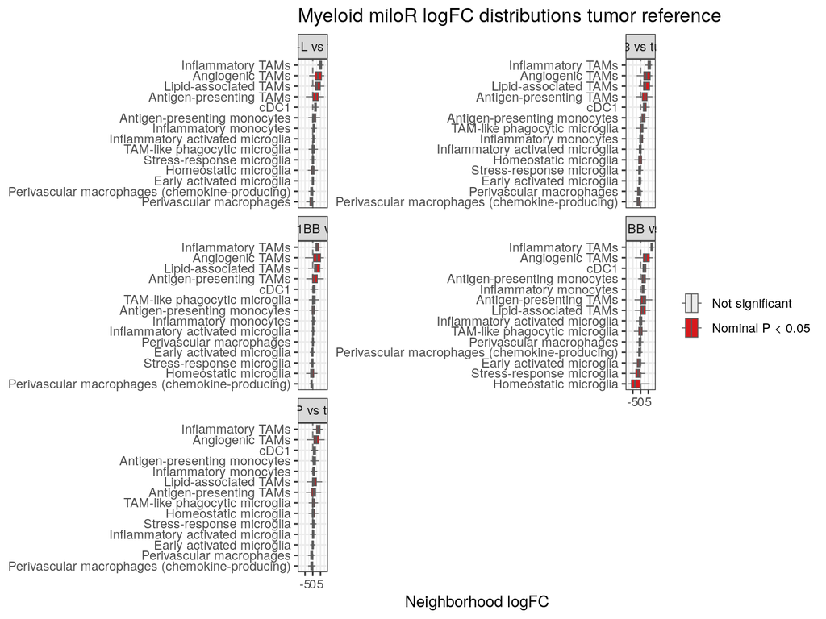

```
## Milo reference condition: STOP
## # A tibble: 5 × 9
##   comparison       n_neighborhoods min_p_value min_fdr min_spatial_fdr n_nominal
##   <chr>                      <int>       <dbl>   <dbl>           <dbl>     <int>
## 1 41BB-L vs STOP              7240    0.00216    1               0.966       310
## 2 B7H3 vs STOP                7240    0.000282   0.383           0.393       707
## 3 CD28-41BB vs ST…            7240    0.000626   1               1           276
## 4 CD8-41BB vs STOP            7240    0.000391   0.180           0.236      1294
## 5 tumor vs STOP               7240    0.00195    1               0.978       293
## # ℹ 3 more variables: n_fdr_0_05 <int>, n_spatial_fdr_0_05 <int>,
## #   max_abs_logFC <dbl>
## No neighborhoods pass SpatialFDR < 0.05 in any contrast.
```

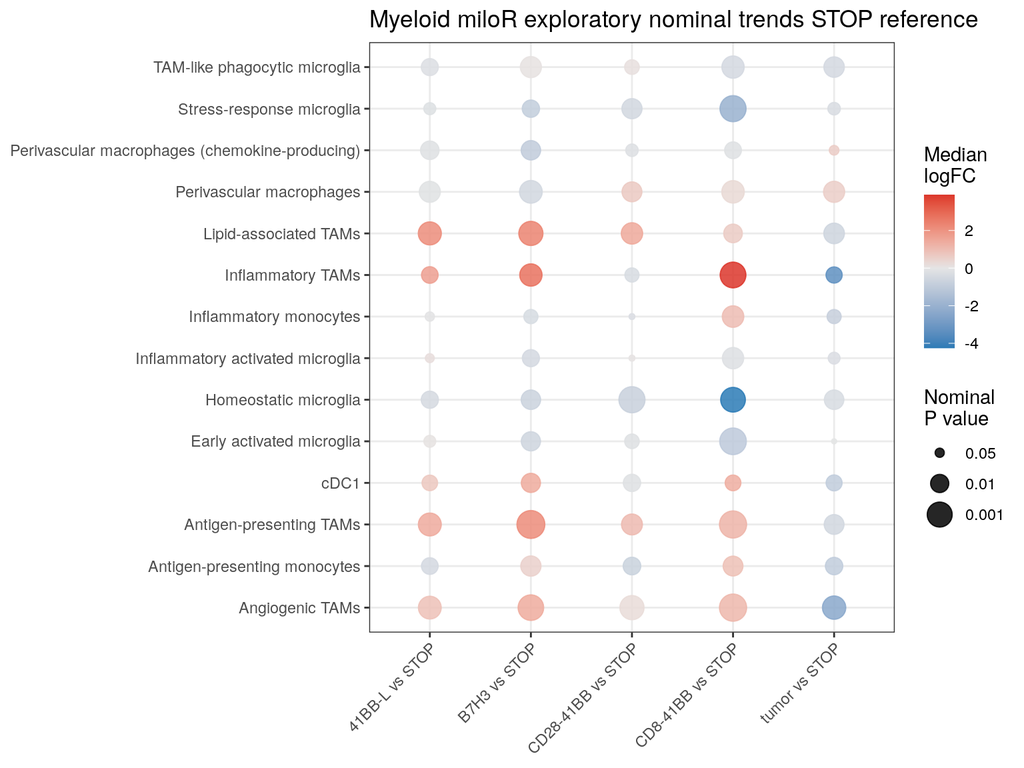

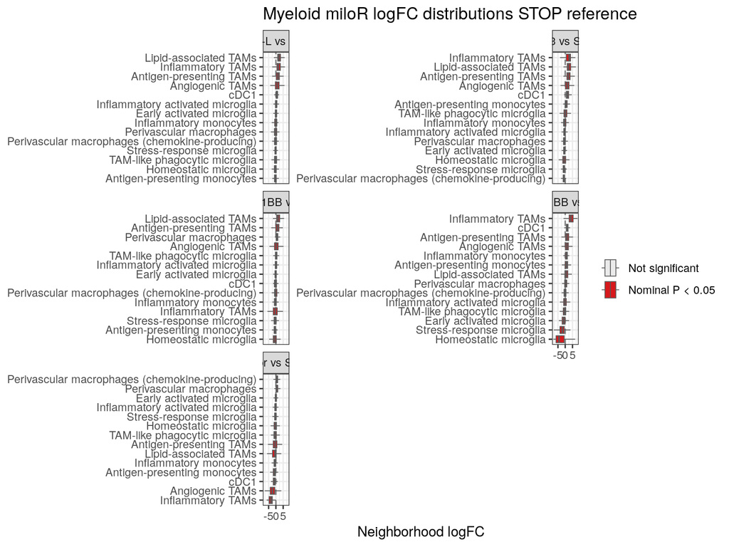

```r
for (reference_condition in names(milo_reference_results)) {
  milo_da_results <- milo_reference_results[[reference_condition]]$da_results
  milo_summary <- summarize_milo_da(milo_da_results)

  milo_da_results <- milo_summary$da_results
  milo_da_threshold_summary <- milo_summary$threshold_summary
  milo_da_effect_summary <- milo_summary$effect_summary

  milo_reference_results[[reference_condition]]$da_results <- milo_da_results
  milo_reference_results[[reference_condition]]$threshold_summary <- milo_da_threshold_summary
  milo_reference_results[[reference_condition]]$effect_summary <- milo_da_effect_summary

  write.table(
    milo_da_threshold_summary,
    file = file.path(results_dir, paste0(analysis_label, "_milor_", safe_label(reference_condition), "_baseline_threshold_summary.tsv")),
    sep = "\t",
    quote = FALSE,
    row.names = FALSE
  )

  write.table(
    milo_da_effect_summary,
    file = file.path(results_dir, paste0(analysis_label, "_milor_", safe_label(reference_condition), "_baseline_effect_summary.tsv")),
    sep = "\t",
    quote = FALSE,
    row.names = FALSE
  )

  cat("Milo reference condition:", reference_condition, "\n")
  print(milo_da_threshold_summary)

  if (all(milo_da_threshold_summary$n_nominal == 0)) {
    cat("No neighborhoods pass nominal PValue < 0.05 in any contrast.\n")
  }
  if (all(milo_da_threshold_summary$n_spatial_fdr_0_05 == 0)) {
    cat("No neighborhoods pass SpatialFDR < 0.05 in any contrast.\n")
  }

  p_milo_effect_dot <- plot_milo_effect_dot(
    milo_da_effect_summary,
    title = paste("Myeloid miloR exploratory nominal trends", reference_condition, "reference")
  )

  print(p_milo_effect_dot)

  ggsave(
    filename = file.path(plot_dir, paste0(analysis_label, "_milor_", safe_label(reference_condition), "_baseline_effect_dotplot.pdf")),
    plot = p_milo_effect_dot,
    width = 8,
    height = 6,
    device = cairo_pdf
  )

  p_milo_logfc_box <- plot_milo_logfc_box(
    milo_da_results,
    milo_da_effect_summary,
    title = paste("Myeloid miloR logFC distributions", reference_condition, "reference")
  )

  print(p_milo_logfc_box)

  ggsave(
    filename = file.path(plot_dir, paste0(analysis_label, "_milor_", safe_label(reference_condition), "_baseline_logFC_boxplot.pdf")),
    plot = p_milo_logfc_box,
    width = 15,
    height = 8,
    device = cairo_pdf
  )
}
```

## Optional Native MiloR Neighborhood Graphs

This optional block saves one native miloR neighborhood graph per contrast. These graphs are useful for exploratory QC but can be visually sparse when no neighborhoods pass the FDR threshold, so they are skipped by default.

```r
if (isTRUE(save_neighborhood_graphs)) {
  for (reference_condition in names(milo_reference_results)) {
    save_optional_milo_graphs(
      milo_obj = milo_obj,
      milo_da_results = milo_reference_results[[reference_condition]]$da_results,
      milo_layout = milo_layout,
      analysis_label = analysis_label,
      reference_condition = reference_condition,
      population_title = "Myeloid",
      plot_dir = plot_dir
    )
  }
} else {
  cat("Skipping native miloR neighborhood graphs. Set params$save_neighborhood_graphs to TRUE to save them.\n")
}
```

```
## Skipping native miloR neighborhood graphs. Set params$save_neighborhood_graphs to TRUE to save them.
```